# Analysis of US Accidents Data

Andrew J. Martinez

2024-11-19

# Introduction

In this analysis, we will explore the US Accidents Dataset available on Kaggle. This dataset contains information about traffic accidents across the United States, including various features such as accident locations, severity, weather conditions, and more. By analyzing this data, we aim to uncover trends and relationships between different factors that contribute to the frequency and severity of traffic accidents in the US, more specifically, in cities within the US.

## Key Details In This Dataset

# Problem/Questions and Approach

The problem we aim to address is understanding the factors that influence the occurrence and severity of traffic accidents in U.S. cities. Specifically, we will examine:

1.Which cities have the highest number of accidents?

2.How do different weather conditions affect accident frequency?

3a.What is the accident severity by weather condition (Top 10)?

3b.What is the accident Severity by City (Top 10).

4.What is the number of accidents during each time of the day?

To address these questions, we will perform exploratory data analysis (EDA) using the US Accidents Dataset. The analysis will include:

- Cleaning and preparing the data for analysis, ensuring that missing values and irrelevant information are handled appropriately.
- Visualizing the relationships between accident frequency, severity, weather conditions, and time of day using bar charts and stacked bar charts.
- Grouping and summarizing the data to identify trends and draw conclusions.

# Libraries Used

I used the following R libraries for data manipulation, exploration, and visualization:

- library(tidyverse) for data manipulation and visualization
- library(ggplot2) for data visualization
- library(dplyr) for data wrangling (manipulation and transformation)
- library(lubridate) for working with dates and times
- library(scales) for better scale formatting in plots
- library(knitr) for dynamic report generation

This produces no problem within the code, therefor this is not something that needs to be fixed. However for other codes that may run into errors with future data exploration, it is important to note this overriding, so we can refer back to these libraries and fix the problem to run these codes.

# Loading the Data

### Data Source:

The dataset used for this analysis is the US Accidents Dataset, which can be accessed from Kaggle through this link [Kaggle US Accidents Dataset](https://www.kaggle.com/datasets/sasikumarg/us-accidents). The dataset was collected from various traffic-related data sources across the United States, aiming to provide insights into traffic accidents, including their locations, causes, and other contributing factors. The data was gathered by Sasikumarg, and it is made publicly available for use in data analysis and research.

```
## Rows: 1,048,575
## Columns: 47
## $ ID                    <chr> "A-2716600", "A-2716601", "A-2716602", "A-271660…
## $ Severity              <int> 3, 2, 2, 2, 2, 3, 2, 2, 2, 2, 2, 2, 2, 2, 2, 2, …
## $ Start_Time            <chr> "08-02-2016 00:37", "08-02-2016 05:56", "08-02-2…
## $ End_Time              <chr> "08-02-2016 06:37", "08-02-2016 11:56", "08-02-2…
## $ Start_Lat             <dbl> 40.10891, 39.86542, 39.10266, 39.10148, 41.06213…
## $ Start_Lng             <dbl> -83.09286, -84.06280, -84.52468, -84.52341, -81.…
## $ End_Lat               <dbl> 40.11206, 39.86501, 39.10209, 39.09841, 41.06217…
## $ End_Lng               <dbl> -83.03187, -84.04873, -84.52396, -84.52241, -81.…
## $ Distance.mi.          <dbl> 3.230, 0.747, 0.055, 0.219, 0.123, 0.500, 1.427,…
## $ Description           <chr> "Between Sawmill Rd/Exit 20 and OH-315/Olentangy…
## $ Number                <int> NA, NA, NA, NA, NA, NA, NA, 1887, NA, NA, NA, NA…
## $ Street                <chr> "Outerbelt E", "I-70 E", "I-75 S", "US-50 E", "I…
## $ Side                  <chr> "R", "R", "R", "R", "R", "R", "R", "R", "R", "R"…
```

[output cut: 34 more lines]

```
##  [1] "ID"                    "Severity"              "Start_Time"
##  [4] "End_Time"              "Start_Lat"             "Start_Lng"
##  [7] "End_Lat"               "End_Lng"               "Distance.mi."
## [10] "Description"           "Number"                "Street"
## [13] "Side"                  "City"                  "County"
## [16] "State"                 "Zipcode"               "Country"
## [19] "Timezone"              "Airport_Code"          "Weather_Timestamp"
## [22] "Temperature.F."        "Wind_Chill.F."         "Humidity..."
## [25] "Pressure.in."          "Visibility.mi."        "Wind_Direction"
## [28] "Wind_Speed.mph."       "Precipitation.in."     "Weather_Condition"
## [31] "Amenity"               "Bump"                  "Crossing"
## [34] "Give_Way"              "Junction"              "No_Exit"
## [37] "Railway"               "Roundabout"            "Station"
## [40] "Stop"                  "Traffic_Calming"       "Traffic_Signal"
## [43] "Turning_Loop"          "Sunrise_Sunset"        "Civil_Twilight"
## [46] "Nautical_Twilight"     "Astronomical_Twilight"
```

# Data Exploration and Cleaning

To ensure accurate analysis, we must clean the dataset:

This dataset was cleaned by handling missing values, converting data types, and filtering out irrelevant columns. For this analysis, the main focus was:

- Removing rows with missing critical data (e.g., Start_Time, City, Weather_Condition).
- Ensuring that the Start_Time column is in a proper date-time format.

### Code:

- Cleaning data to ensure no missing values in key columns (Severity, Weather_Condition, City)
- Grouping data to ease the process of code for questions containing factors like weather and severity

##### Remove rows with NA in important columns (Start_Time, city, weather_condition):

accidents_data_clean <- accidents_data %>% filter(!is.na(Start_Time) & !is.na(City) & !is.na(Weather_Condition))

##### Limit to top 10 weather conditions to ensure a better visual understanding of the graphs:

top_weather_conditions <- accidents_by_weather %>% group_by(Weather_Condition) %>% summarise(Accident_Count = sum(Accident_Count)) %>% arrange(desc(Accident_Count)) %>% head(10)

##### Filter to only include top 10 weather conditions:

accidents_by_weather_top <- accidents_by_weather %>% filter(Weather_Condition %in% top_weather_conditions$Weather_Condition)

##### Reorder Severity factor to ensure correct ordering (from 1 to 4):

accidents_by_weather_topSeverity <- factor(accidents_by_weather_top$Severity, levels = c(1, 2, 3, 4))

##### Group accidents by weather condition and severity:

accidents_by_weather <- accidents_data_clean %>% group_by(Weather_Condition, Severity) %>% summarise(Accident_Count = n()) %>% arrange(desc(Accident_Count))

# Filtering My Data Continued…

##### Filter out rows where weather_condition is NA or empty before grouping for Question 2

accidents_by_weather <- accidents_data_clean %>% filter(!is.na(Weather_Condition) & Weather_Condition != ““) %>% group_by(Weather_Condition) %>% summarise(Accident_Count = n()) %>% arrange(desc(Accident_Count))

##### Ensure the time columns are in the correct format and extract the start hour for Question 4

accidents_data_time <- accidents_data_clean %>% mutate( Start_Time2 = dmy_hm(Start_Time), # Convert Start_Time to date-time End_Time = dmy_hm(End_Time), # Convert End_Time to date-time Start_Hour = hour(Start_Time2) # Extract hour from Start_Time )

accidents_data_time %>% filter(is.na(Start_Time2)) %>% select(Start_Time) %>% slice_sample(n = 20)

##### Filter out rows where weather_condition is NA or empty before grouping for Question 2

accidents_by_weather <- accidents_data_clean %>% filter(!is.na(Weather_Condition) & Weather_Condition != ““) %>% group_by(Weather_Condition) %>% summarise(Accident_Count = n()) %>% arrange(desc(Accident_Count))

##### Ensure the time columns are in the correct format and extract the start hour for Question 4

accidents_data_time <- accidents_data_clean %>% mutate( Start_Time2 = dmy_hm(Start_Time), # Convert Start_Time to date-time End_Time = dmy_hm(End_Time), # Convert End_Time to date-time Start_Hour = hour(Start_Time2) # Extract hour from Start_Time )

##### accidents error for code above, says there are 34000 missing but it is only 3% of our data.

accidents_data_time %>% filter(is.na(Start_Time2)) %>% select(Start_Time) %>% slice_sample(n = 20)

```
##    Start_Time
## 1     06:00.0
## 2     37:00.0
## 3     32:36.0
## 4     11:00.0
## 5     20:02.0
## 6     53:00.0
## 7     55:53.0
## 8     31:52.0
## 9     54:00.0
## 10    39:00.0
## 11    23:00.0
## 12    51:24.0
## 13    17:00.0
## 14    35:00.0
## 15    39:16.0
## 16    35:00.0
## 17    09:50.0
## 18    36:17.0
## 19    09:47.0
## 20    58:40.0
```

##### Accidents Error Shown Above

# Question 1. Most Accident-Prone Cities

To explore which Cities have the highest number of accidents, we will group the data by city and visualize the total number of accidents.

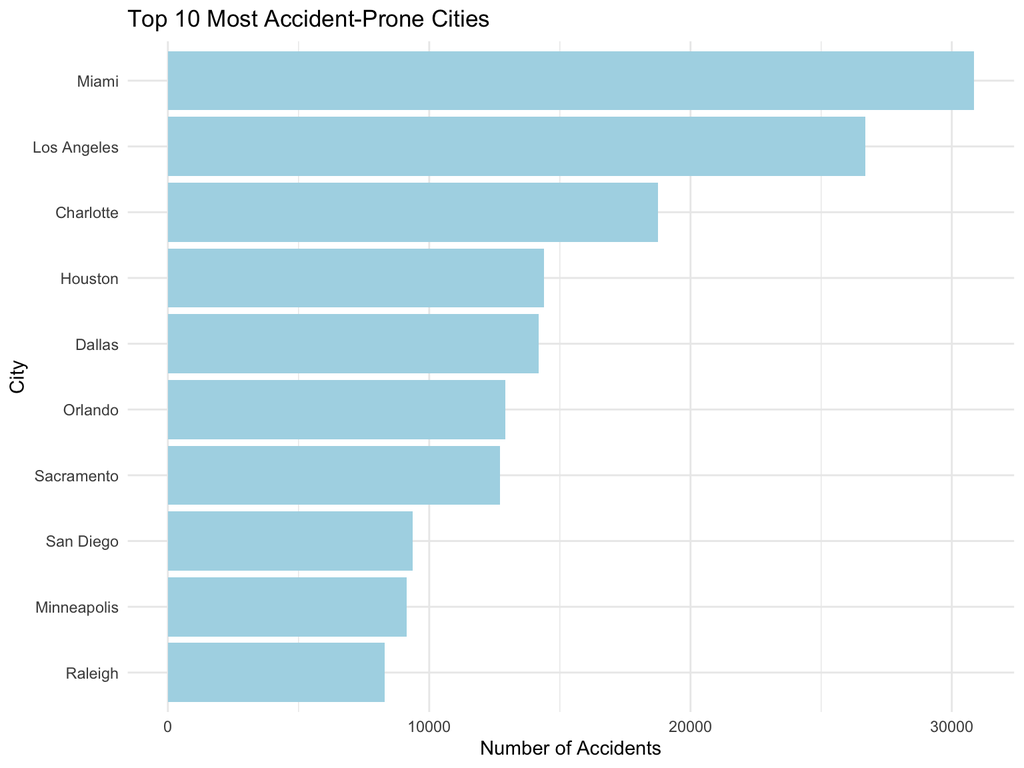

# Question 2. Weather Conditions and Accidents

Next, we examine how different weather conditions affect accident frequency by grouping the data by Weather_Condition and summarizing the accident counts.

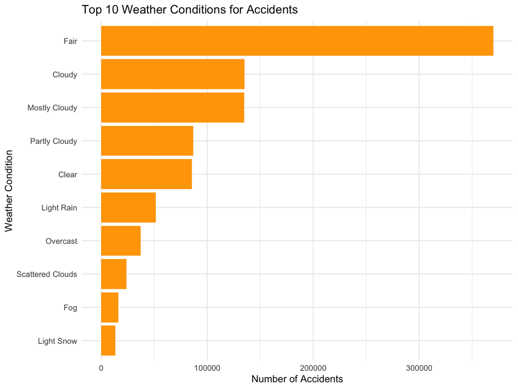

# Question 3a. Accident Severity by Weather Contition

Now we analyze the severity of accidents under different weather conditions by creating a stacked bar chart that shows the breakdown of accident severity by weather condition.

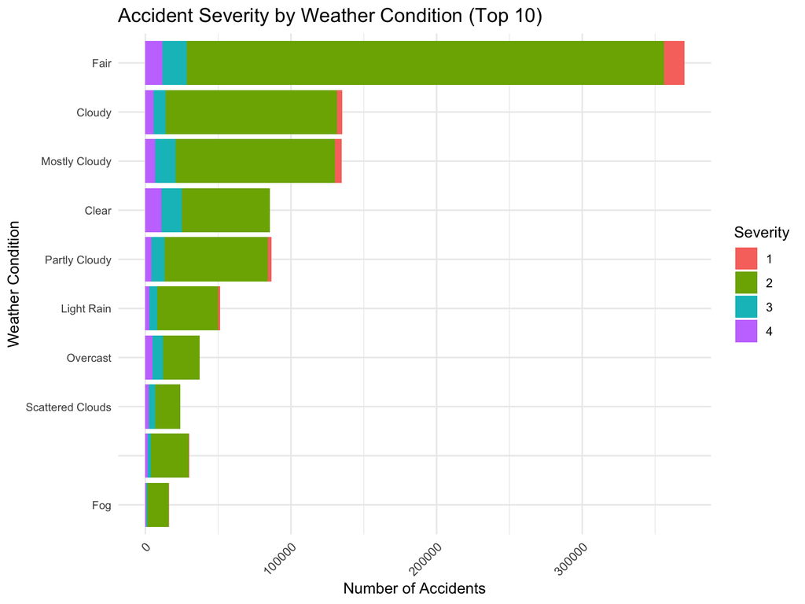

# Question 3b. Accident Severity by City

We now explore how accident severity varies across the top 10 cities with the highest number of accidents.

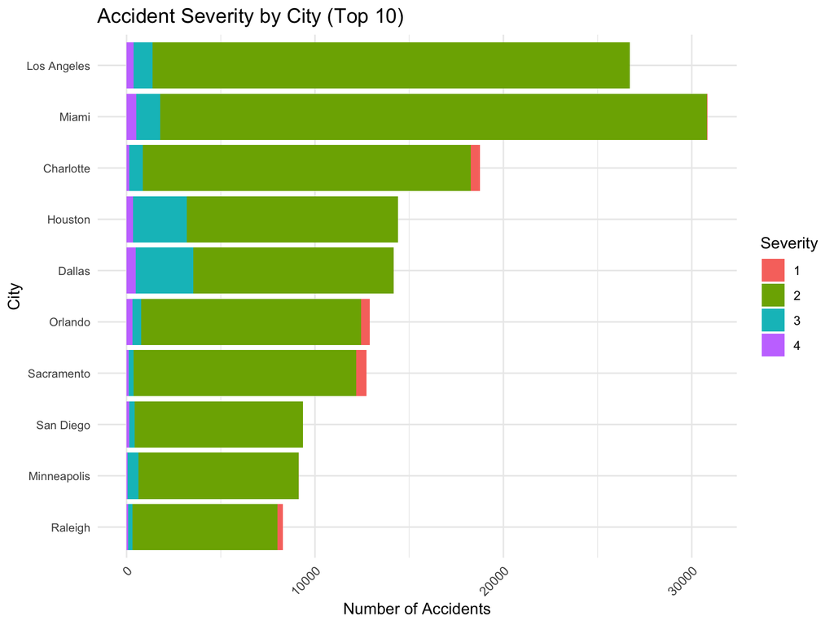